# Lab 1

Annie Adams

2024-04-05

## Assignment (Due Tuesday 4/9 11:59pm)

Reminder: Please suppress all long and extraneous output from your submissions (ex: lists of tokens).

1. Create a free New York Times account (https://developer.nytimes.com/get-started)
2. Pick an interesting environmental key word(s) and use the {jsonlite} package to query the API. Pick something high profile enough and over a large enough time frame that your query yields enough articles for an interesting examination.

### Load packages and API

```r
library(jsonlite) #convert results from API queries into R-friendly formats
library(tidyverse) #tidy
library(tidytext) #text data management and analysis
library(ggplot2) #plot word frequencies and publication dates
library(SnowballC)

#assign API key.  When you create a NYT Dev account, you will be given a key
API_KEY <- "ERo5sxAymDAb3wBUjmo3h2ifSM1p552m"


#create the query url
url <- paste("http://api.nytimes.com/svc/search/v2/articlesearch.json?q=haaland&api-key=",API_KEY, sep ="")

#send the request, receive the response, and flatten
t <- fromJSON(url, flatten = T)
```

```r
enviro_term1 <- "carbon"
#enviro_term2 <- "plastic"
begin_date <- "20210120"
end_date <- "20230404"

#construct the query url using API operators
baseurl <- paste0("http://api.nytimes.com/svc/search/v2/articlesearch.json?q=",
                  enviro_term1,
                  "&begin_date=", begin_date,
                  "&end_date=", end_date,
                  "&facet_filter=true",
                  "&api-key=", API_KEY)

#examine our query url
baseurl
```

```
## [1] "http://api.nytimes.com/svc/search/v2/articlesearch.json?q=carbon&begin_date=20210120&end_date=20230404&facet_filter=true&api-key=ERo5sxAymDAb3wBUjmo3h2ifSM1p552m"
```

3. Recreate the publications per day and word frequency plots using the first paragraph field. This time filter on the response.docs.news_desk variable to winnow out irrelevant results.

### Publications per day

```r
#bind the pages and create a tibble from nytDat
nyt_df <- bind_rows(pages)



tokenized <- nyt_df %>%
  filter(response.docs.news_desk %in% c("Climate", "OpEd", "Washington")) %>%
unnest_tokens(word, response.docs.lead_paragraph) #word is the new column, paragraph is the source
```

### Publication per day plot

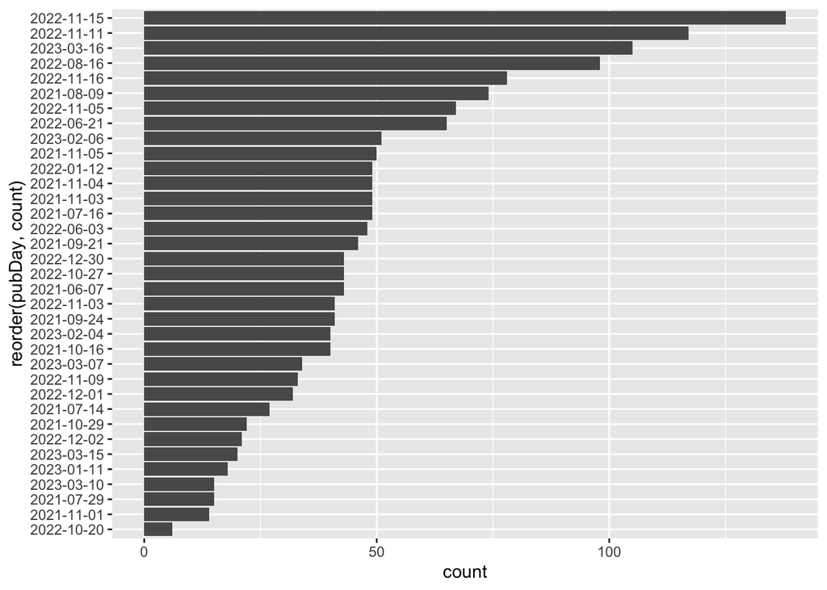

```r
tokenized %>%
  mutate(pubDay=gsub("T.*","",response.docs.pub_date)) %>%
  group_by(pubDay) %>%
  summarise(count=n()) %>%
  ggplot() +
  geom_bar(aes(x=reorder(pubDay, count), y=count), stat="identity") +
  coord_flip() #bring date so bars go lengthwise
```

### Word frequency

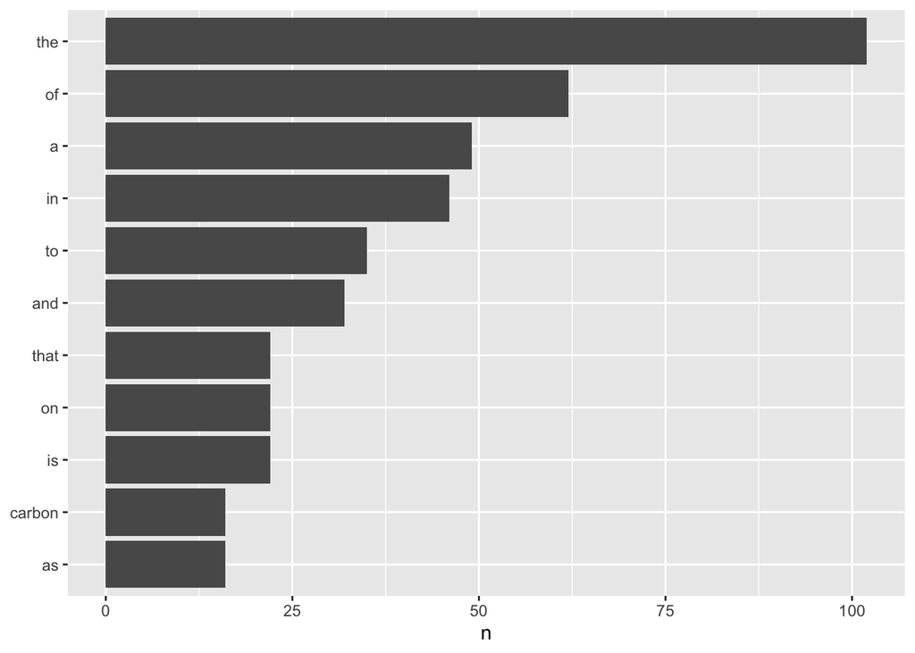

```r
tokenized %>%
  count(word, sort = TRUE) %>%
  filter(n > 15) %>%
  mutate(word = reorder(word, n)) %>%
  ggplot(aes(n, word)) +
  geom_col()+
  labs(y = NULL)
```

- Make some (at least 3) transformations to the corpus including: add context-specific stopword(s), stem a key term and its variants, remove numbers)

### Add context specific stopwords

```r
tokenized <- tokenized %>%
  anti_join(get_stopwords(source = "snowball"))
```

[figure not shown]

```r
#inspect the list of tokens (words)
#tokenized$word

#remove all numbers
clean_tokens <- str_remove_all(tokenized$word, "[:digit:]")

#remove s contractions
clean_tokens <- gsub("’s", '', clean_tokens)


tokenized$clean <- clean_tokens

tokenized %>%
  count(clean, sort = TRUE) %>%
  mutate(clean = reorder(clean, n)) %>%
  ggplot(aes(n, clean)) +
  geom_col() +
  labs(y = NULL)
```

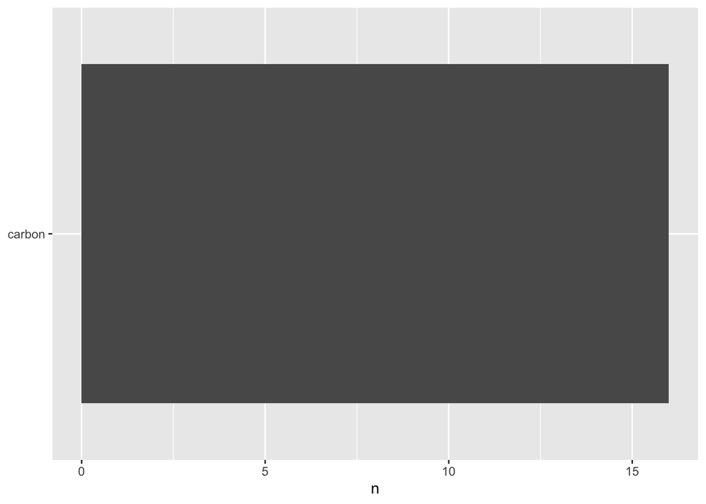

```r
#remove the empty strings
tib <-subset(tokenized, clean!="")

#reassign
tokenized <- tib

#try again
tokenized %>%
  count(clean, sort = TRUE) %>%
  filter(n > 15) %>%
  mutate(clean = reorder(clean, n)) %>%
  ggplot(aes(n, clean)) +
  geom_col() +
  labs(y = NULL)
```

4. Recreate the publications per day and word frequency plots using the headlines variable (response.docs.headline.main). Compare the distributions of word frequencies between the first paragraph and headlines. Do you see any difference?

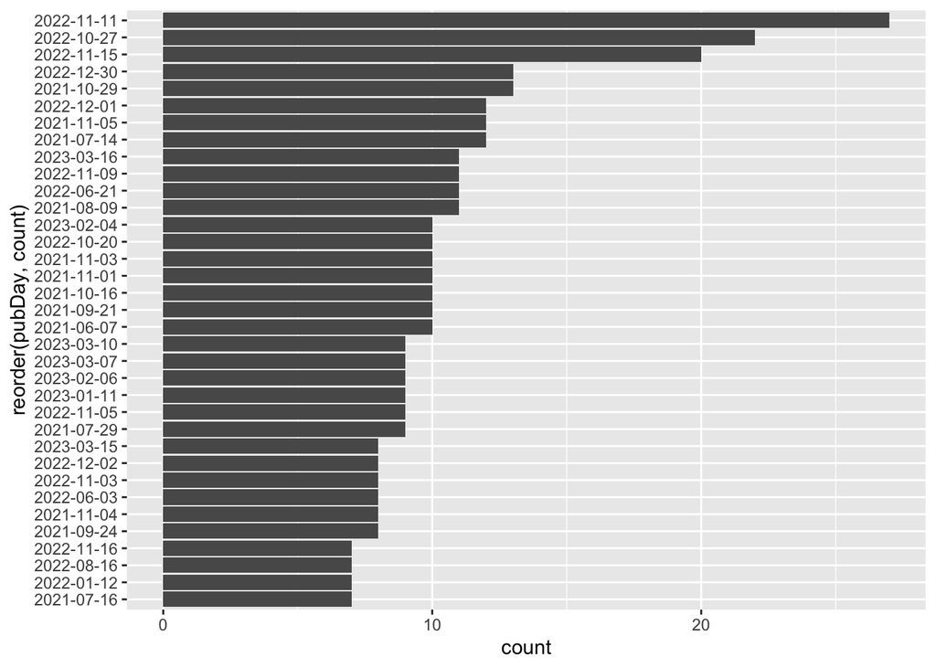

```r
#Re-assigning to use the headlines variable ---
nyt_df2<-
nyt_df %>%
  filter(response.docs.news_desk %in% c("Climate", "OpEd", "Washington")) %>%
unnest_tokens(word, response.docs.headline.main)


#Publications per day plot ---
nyt_df2 %>%
  mutate(pubDay=gsub("T.*","",response.docs.pub_date)) %>% #global substitution to pull out time portion of dates (with T.)
  filter(response.docs.news_desk %in% c("Climate", "Washington", "OpEd")) %>%
  group_by(pubDay) %>%
  summarise(count=n()) %>%
  ggplot() +
  geom_bar(aes(x=reorder(pubDay, count), y=count), stat="identity") +
  coord_flip() #bring date so bars go longwise
```

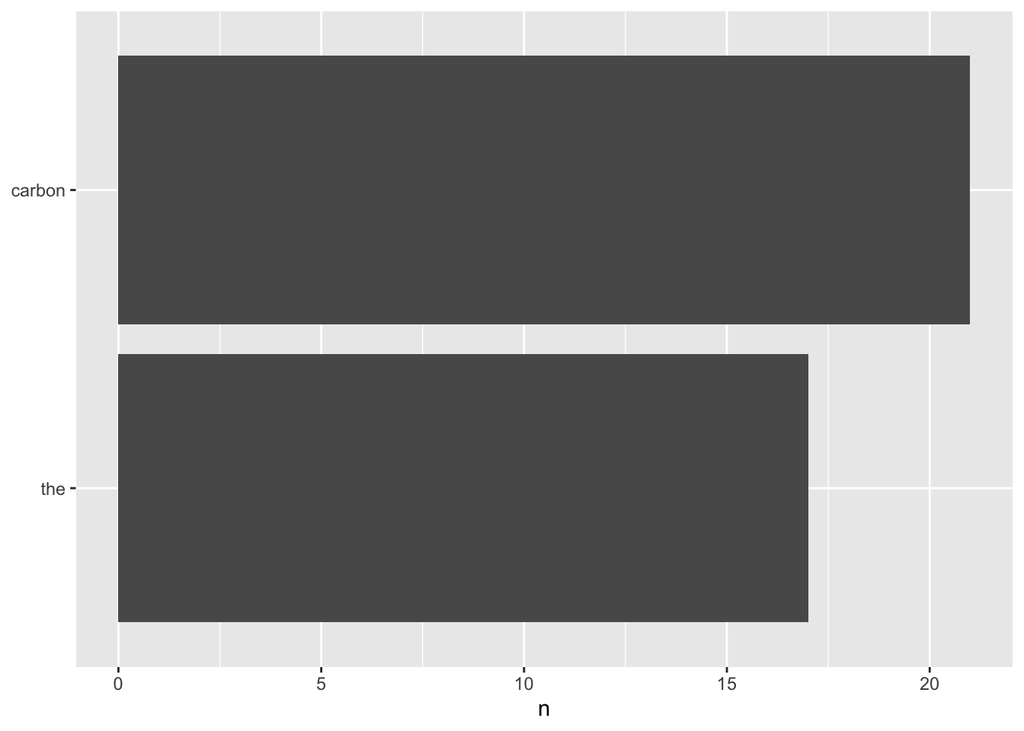

```r
#Word frequency plot ---
nyt_df2 %>%
  count(word, sort = TRUE) %>% #calculating # of words
  filter(n > 15) %>%
  mutate(word = reorder(word, n)) %>%  #ordering by n for frequency to get most common words
  ggplot(aes(n, word)) +
  geom_col() +
  labs(y = NULL)
```